# Recap of Lab 8

Søren Helweg Dam, Daniel Romero

2026

# Exercises recap

## Lab 8 Learning Objectives

- Prepare a simple R package for distributing documented functions
- Explain the terms `Repository`, `Dependency`, and `Namespace`
- Implement testing in an R package
- Collaboratively work on an R package on GitHub

## Core Concepts

**What is an R package?**

- A `shareable` collection of `documented` code and/or data

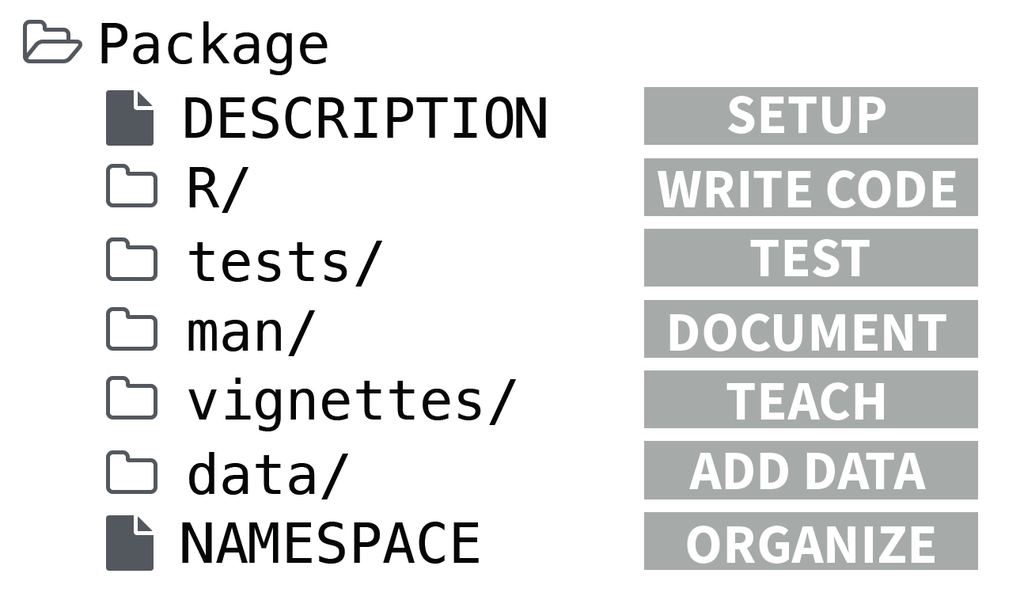

## Core Concepts

**What is a repository?**

- Specialized storage systems designed to manage source code and other software development assets
- e.g. a centralized folder with `git` version control and stored in GitHub

## Core Concepts

**What is a dependency?**

Any external thing your package relies on to work (most commonly, another package).

With `usethis`, we add dependencies like this:

```r
usethis::use_package("package_name")
```

We should try to avoid dependencies as much as we can (within reason), because:

## Core Concepts

**What is a namespace?**

- A collection of names used to identify specific objects or functions
- From the perspective of a package, it is the names of every function or data object that will become available when you do `library("your_package")`
- R packages export names through the `NAMESPACE` file:

```r
# Generated by roxygen2: do not edit by hand

export(DNA_to_RNA)
export(amino_acid_counts_plot)
export(random_DNA)
export(subdivide_codons)
export(translate)
```

## Core Concepts

**What is a namespace?**

- A collection of names used to identify specific objects or functions
- From the perspective of a package, it is the names of every function or data object that will become available when you do `library("your_package")`
- R packages export names through the `NAMESPACE` file:

```r
# Generated by roxygen2: do not edit by hand

export(DNA_to_RNA)
export(amino_acid_counts_plot)
export(random_DNA)
export(subdivide_codons)
export(translate)
```

- Note: **The local namespace of a function is a different thing!** You can import functions from other packages into the function’s namespace with `@importFrom package function` and `@import package` (we did this in function 5).

## The package you built

[interactive chart not shown]

## DESCRIPTION

```bash
Package: centralDogma
Type: Package
Title: Central Dogma
Version: 0.1.0
Description: simple R package that replicates the central dogma of molecular biology.
License: MIT + file LICENSE
Encoding: UTF-8
LazyData: true
Imports:
    ggplot2,
    stringr
Depends:
    R (>= 4.0)
```

# Exercises

## Initial setup

- We created the R package project (RStudio simply creates the minimal files required for an R package)
- Added basic information to the `DESCRIPTION` file
- Connected it to GitHub:

```r
usethis::use_git_remote(name = "origin", "https://github.com/rforbiodatascienceYY/group_X_package.git", overwrite = TRUE)
```

## Registering data objects

```r
codon_table = c("UUU" = "F", "UCU" = "S", "UAU" = "Y", "UGU" = "C", ...)

usethis::use_data(codon_table, overwrite = TRUE, internal = TRUE)
```

## Implementing functions and their documentation

```r
#' Create a string of random DNA
#'
#' @param DNA_length length of the randomly created DNA
#'
#' @returns a string of random DNA
#' @export
random_DNA <- function(DNA_length){
  DNA_vec <- sample(c("A", "T", "G", "C"), size = DNA_length, replace = TRUE)
  DNA_str <- paste0(DNA_vec, collapse = "")
  return(DNA_str)
}
```

Those comments on top of the function is how an R package makes its documentation show up when running `?function_name` in the Console.

`devtools::document()` converts those comments into `.Rd` files in the `man` folder of the package using `roxygen2`. Otherwise you would have to write them yourself…

[figure not shown]

## Testing

The purpose of testing:

- They serve as sanity checks
- Future proofing: ensure that the behavior doesn’t change when you update your function in the future
- Ensuring that a bug you fixed doesn’t get re-introduced in a future update
- Defining the behavior of your function before you even start coding it (*test-driven development*)

## Testing

With `testhat`, we have a collection of `expect_*` functions that check for specific conditions

```r
test_that("rnadom DNA has the correct length", {
  DNA_length <- 100
  generated_DNA <- random_DNA(DNA_length)

  expect_equal(nchar(generated_DNA), DNA_length)
})

test_that("all letters are valid DNA", {
  DNA_letters <- c("A", "C", "T", "G")

  generated_DNA <- random_DNA(400)
  generated_DNA <- strsplit(generated_DNA, "")[[1]] # transform to vector form

  is_valid_letter <- generated_DNA %in% DNA_letters
  expect_true(all(is_valid_letter))
})
```

[figure not shown]

## Vignettes (group assignment)

- A vignette is a little “tutorial” that explains the basic functionality of a package
- It is **not** a replacement for documentation, but rather a starting point for new users

[interactive chart not shown]

# Errors and challenges

## The NAMESPACE file

```r
> devtools::document()
ℹ Updating cdogma documentation
ℹ Loading cdogma
Warning message:
Skipping NAMESPACE
✖ It already exists and was not generated by roxygen2.
```

## The NAMESPACE file

```r
> devtools::document()
ℹ Updating cdogma documentation
ℹ Loading cdogma
Warning message:
Skipping NAMESPACE
✖ It already exists and was not generated by roxygen2.
```

**Solution:** Delete `NAMESPACE` file and rerun `devtools::document()`

## The NAMESPACE file

```r
# Generated by roxygen2: do not edit by hand

<<<<<<< HEAD
export(function_x)
=======
export(function_y)
>>>>>>> e34c9e2848142b2afa6394733438e78434483ebc
```

## The NAMESPACE file

```r
# Generated by roxygen2: do not edit by hand

<<<<<<< HEAD
export(function_x)
=======
export(function_y)
>>>>>>> e34c9e2848142b2afa6394733438e78434483ebc
```

**Solution:** Fix merge conflicts

## Failing `devtools::check()`

```r
❯ checking examples ... ERROR
  Running examples in ‘cdogma-Ex.R’ failed
  The error most likely occurred in:

  > base::assign(".ptime", proc.time(), pos = "CheckExEnv")
  > ### Name: hello
  > ### Title: Hello, World!
  > ### Aliases: hello
  >
  > ### ** Examples
  >
  > hello()
  Error in hello() : could not find function "hello"
  Execution halted
```

## Failing `devtools::check()`

```r
❯ checking examples ... ERROR
  Running examples in ‘cdogma-Ex.R’ failed
  The error most likely occurred in:

  > base::assign(".ptime", proc.time(), pos = "CheckExEnv")
  > ### Name: hello
  > ### Title: Hello, World!
  > ### Aliases: hello
  >
  > ### ** Examples
  >
  > hello()
  Error in hello() : could not find function "hello"
  Execution halted
```